# Clase 4: Consolidando lo aprendido mapeando la (In)Justicia Ambiental del Cambio Climático a escala global

## Resultado final

Los mapas finales deberían verse algo así (con tu propia elección de colores y CRS):

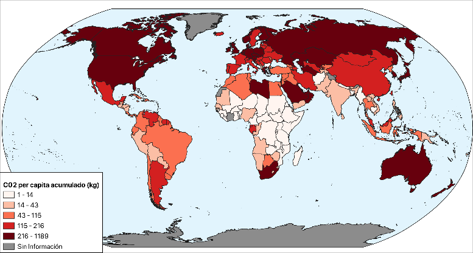

Mapa final — CO₂ per cápita acumulado (kg), 1990–2020

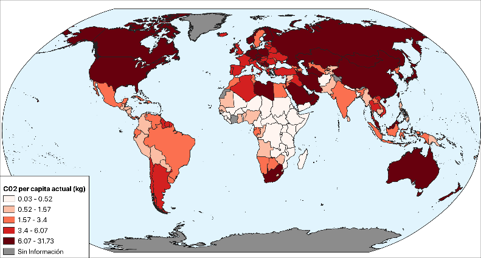

Mapa final — CO₂ per cápita actual (kg), 2020

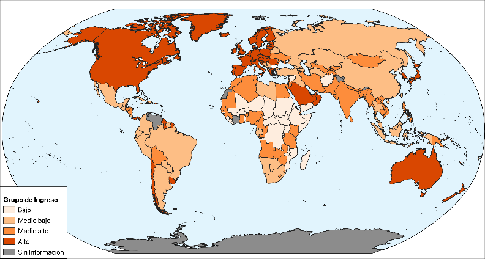

Mapa final — Grupo de ingreso por país

¡Listo! Has finalizado tus mapas. Recuerda guardar tu trabajo para poder utilizarlo en la entrega de tu próximo portafolio.

## Preguntas guía para reflexión

**ImportantePreguntas guía para reflexión**

- **Emisiones actuales vs. acumuladas:** Comparando tus mapas de emisiones actuales y acumuladas, ¿qué países aparecen como grandes emisores en uno pero no en el otro? ¿Qué implica esto para la discusión sobre **responsabilidad histórica** vs. responsabilidad actual en las negociaciones climáticas?
- **Ingreso y emisiones:** Observando tus tres mapas en conjunto, ¿qué relación puedes identificar entre el nivel de ingreso de un país y sus emisiones de CO₂? ¿Existen excepciones a este patrón? ¿Qué nos dice esto sobre la relación entre **desarrollo económico y huella de carbono**?
- **Justicia climática:** El artículo de [*Our World in Data*](https://ourworldindata.org/co2-emissions) plantea distintas formas de medir las emisiones (totales, per cápita, acumuladas, basadas en consumo). ¿Cómo cambia la narrativa de **quién es responsable** dependiendo de la métrica que se use? ¿Cuál te parece más justa y por qué?
- **Desigualdad y vulnerabilidad:** Como vimos en la clase, quienes menos contribuyen al cambio climático suelen ser los más afectados. A partir de tus mapas, ¿puedes identificar esta paradoja entre los países del **Sur y Norte Global**?